# tmap in a nutshell

With the tmap package, thematic maps can be generated with great flexibility. The syntax for creating plots is similar to that of `ggplot2`. The tmap package also contains many facility functions for reading and processing shape files (see overview). This vignette will focus on the core business of tmap, which is plotting maps. It’s also possible to plot maps interactively; see `vignette("tmap-modes")`.

### Shape objects

We refer to **shape objects** as objects from the class `Spatial` or `Raster`, respectively from the `sp` and the `raster` package. The supported subclasses are:

|  | Without data | With data |
| --- | --- | --- |
| Polygons | SpatialPolygons | SpatialPolygonsDataFrame |
| Points | SpatialPoints | SpatialPointsDataFrame |
| Lines | SpatialLines | SpatialLinesDataFrame |
| Raster | SpatialGrid | SpatialGridDataFrame |
| Raster | SpatialPixels | SpatialPixelsDataFrame |
| Raster |  | RasterLayer |
| Raster |  | RasterBrick |
| Raster |  | RasterStack |

Obviously, shape objects with data (the right-hand side column) are recommended, since data is what we want to show.

Load shape object of Europe (contained in this package):

```r
data(Europe)
```

Shape objects in ESRI format can be read with `read_shape` and written with `write_shape`. Projection can be get and set with `get_projection` and `set_projection` respectively. Note: projections can also directly (and temporarily) be set in the plotting method (as argument of `tm_shape`, see below).

### Quick thematic map

The plotting syntax is based on that of `ggplot`. The `qtm` function is `tmap`’s equivalent to `ggplot2`’s `qplot`. The first, and only required argument is a shape object:

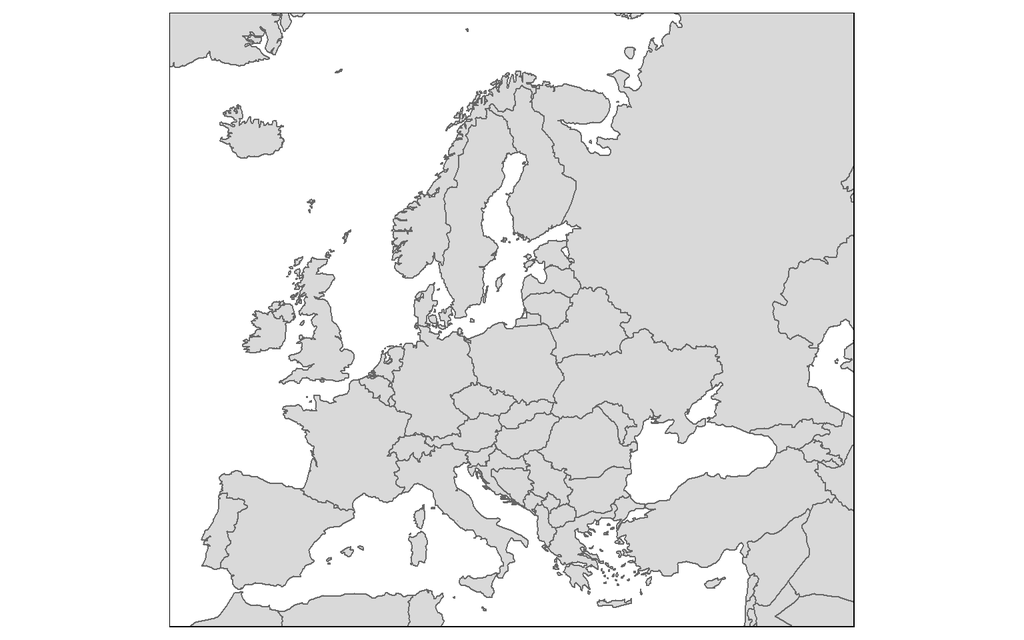

```r
qtm(Europe)
```

So, by default, the polygons (in case the shape object is a SpatialPolygonsDataFrame) are filled with light grey, and the polygon borders are drawn in dark grey.

A choropleth is created with the following code:

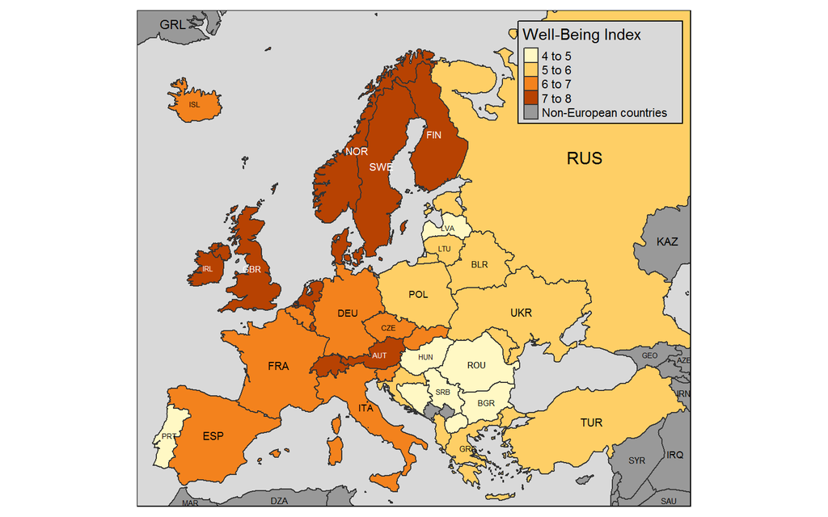

```r
qtm(Europe, fill="well_being", text="iso_a3", text.size="AREA", root=5, fill.title="Well-Being Index",
    fill.textNA="Non-European countries",
    format="Europe", style="gray")
```

The function `qtm` offers the same flexibility as the main plotting method (to be described next). However, for more complex plots, the main plotting method is recommended for tis readability.

### Plotting with tmap elements

The main plotting method, the equivalent to `ggplot2`’s `ggplot`, consists of elements that start with `tm_`. The first element to start with is `tm_shape`, which specifies the shape object. Next, one, or a combination of the following drawing layers should be specified:

| Drawing layer | Description | Aesthetics |
| --- | --- | --- |
| `tm_fill` | Fills the polygons | col |
| `tm_borders` | Draws polygon borders | col, lwd |
| `tm_polygons` | Combination of `tm_fill` and `tm_borders` | col |
| `tm_bubbles` | Draws bubbles | size, col |
| `tm_dots` | Draws dots | col |
| `tm_lines` | Draws polylines | col, lwd |
| `tm_raster` | Draws a raster | col |
| `tm_text` | Add text labels | text, size, col |

Both constant values as well as data variable names can be assigned to the aesthetic arguments (except for `tm_borders`). For instance, `tm_fill(col="blue")` colors all polygons blue, while `tm_fill(col="var1")`, where `"var1"` is the name of a data variable in the shape object, creates a choropleth. If a vector of constant values or variable names are provided, small multiples are created.

The following layers are map attributes:

| Attribute layer | Description |
| --- | --- |
| `tm_grid` | Add coordinate grid lines |
| `tm_credits` | Add credits text label |
| `tm_compass` | Add map compass |
| `tm_scale_bar` | Add scale bar |

The last plot is reproduced as follows:

```r
tm_shape(Europe) +
    tm_fill("well_being", textNA="Non-European countries", title="Well-Being Index") +
    tm_borders() +
    tm_text("iso_a3", size="AREA", root=5) +
tm_format_Europe() +
tm_style_grey()
```

We refer to `tm_shape` and its subsequent drawing layers as a **group**. Multiple groups can be stacked. To illustrate this, let’s create a topographic map of Europe:

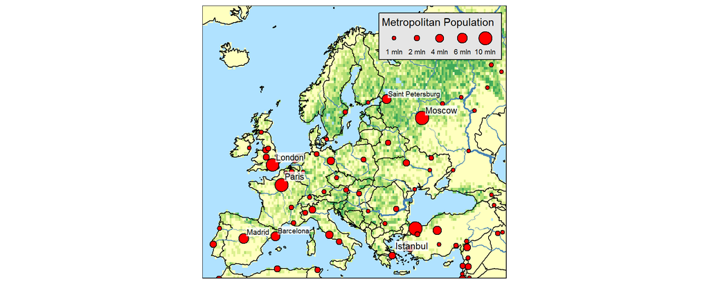

```r
data(land, rivers, metro)

tm_shape(land) +
    tm_raster("trees", breaks=seq(0, 100, by=20), legend.show = FALSE) +
tm_shape(Europe, is.master = TRUE) +
    tm_borders() +
tm_shape(rivers) +
    tm_lines(lwd="strokelwd", scale=5, legend.lwd.show = FALSE) +
tm_shape(metro) +
    tm_bubbles("pop2010", "red", border.col = "black", border.lwd=1,
        size.lim = c(0, 11e6), sizes.legend = c(1e6, 2e6, 4e6, 6e6, 10e6),
        title.size="Metropolitan Population") +
    tm_text("name", size="pop2010", scale=1, root=4, size.lowerbound = .6,
        bg.color="white", bg.alpha = .75,
        auto.placement = 1, legend.size.show = FALSE) +
tm_format_Europe() +
tm_style_natural()
```

Things to learn from this code:

- This plot has 4 groups of layers, respectively from the shape objects land, Europe, rivers, and metro. The order of (groups of) layers corresponds to the plotting order.
- The shape objects can have different projections, and can also cover different areas (bounding boxes). Both the projection and the covered area are by default taken from shape object defined in the first `tm_shape`. Notice that the rivers shape object also contains rivers outside Europe: see `qtm(rivers)`. Use `tm_shape`’s `is.master` argument to take the projection and covered area from other shape objects.
- The element `tm_layout` controls all layout options such as fonts, legends, margins, and colors. The element `tm_format_Europe` is a wrapper function with some other defaults that are tailored for Europe: for instance, the left inner margin is increased to make space for the legend. The element `tm_layout_natural` is another wrapper function of `tm_layout` used to specify map-independent layout layout settings, such as default colors. See also layout.

### Small multiples

Small multiples are generated in two ways:

1. By assigning multiple values to at least one of the aesthetic arguments:

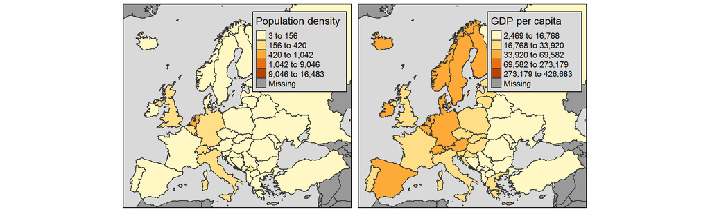

```r
tm_shape(Europe) +
    tm_polygons(c("pop_est_dens", "gdp_cap_est"), style="kmeans",
        title=c("Population density", "GDP per capita")) +
tm_format_Europe() +
tm_style_grey()
```

2. By defining a group-by variable in `tm_facets`:

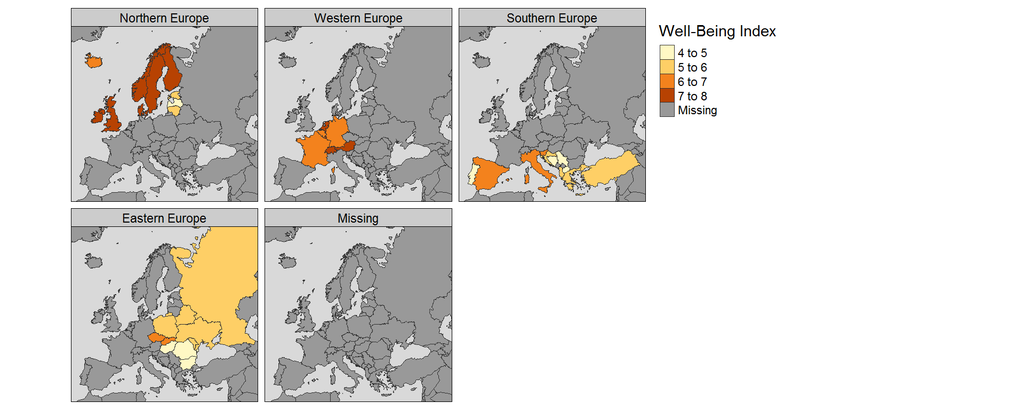

```r
tm_shape(Europe) +
    tm_polygons("well_being", title="Well-Being Index") +
    tm_facets("part") +
tm_style_grey()
```

Notice that this plot has a different layout than the previous one. In the last plot, panels are used, and the legend is shown next to the maps. These options can be changed with the arguments `panel.show` and `legend.outside` of `tm_layout`. By default, the panel/external legend layout is used when the group-by variable is specified, since in that case, the multiples share a common legend.

The scales of each aesthetic argument can be set to either fixed or free, and also, the coordinate ranges of the small multiples:

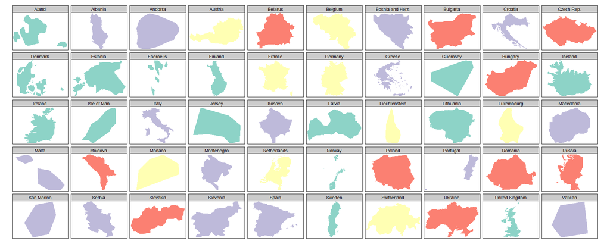

```r
tm_shape(Europe[Europe$continent=="Europe",]) +
    tm_fill("part", legend.show = FALSE) +
    tm_facets("name", free.coords=TRUE, drop.units=TRUE)
```

The argument `drop.units` is used to drop all non-selected spatial units. If `drop.shapes=FALSE` then neighboring countries are also visible.

### Map layout

The layout of the thematic map can be changed with `tm_layout` or one of its wrapper functions. In the next example we use two of these wrapper functions, one for the overall format of world maps, and one for the legend.

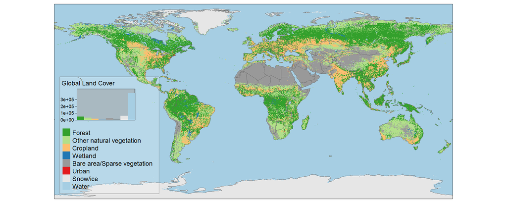

```r
data(land)
data(World)
pal8 <- c("#33A02C", "#B2DF8A", "#FDBF6F", "#1F78B4", "#999999", "#E31A1C", "#E6E6E6", "#A6CEE3")
tm_shape(land, ylim = c(-88,88), relative=FALSE) +
    tm_raster("cover_cls", palette = pal8, title="Global Land Cover", legend.hist=TRUE, legend.hist.z=0) +
tm_shape(World) +
    tm_borders() +
tm_format_World(inner.margins=0) +
tm_legend(text.size=1,
          title.size=1.2,
          position = c("left","bottom"),
          bg.color = "white",
          bg.alpha=.2,
          frame="gray50",
          height=.6,
          hist.width=.2,
          hist.height=.2,
          hist.bg.color="gray60",
          hist.bg.alpha=.5)
```

The wrapper functions starting with `tm_format_` specify the format for a specifc shape. In the tmap package, a couple of them are included, for instance `tm_format_World` that is taylored for world maps. It’s also possible to create your own wrapper function for shapes that you will use frequently.

Besides the shape-dependent `tm_format_` wrapper functions, tmap also contains wrapper functions for shape-independent styles.

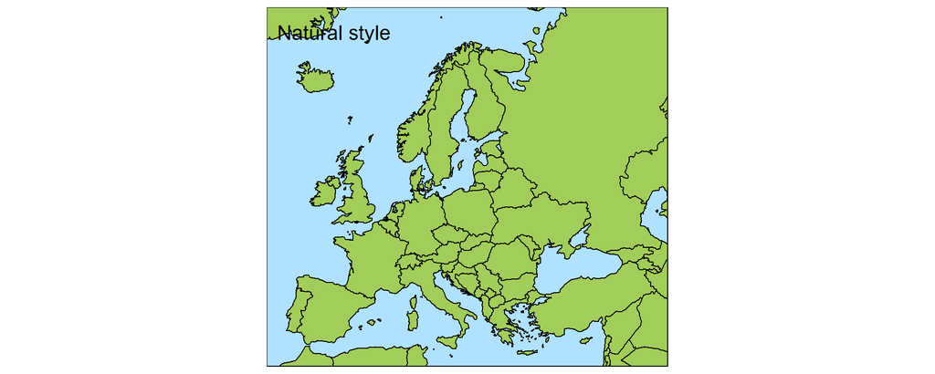

```r
qtm(Europe, style="natural", title="Natural style") # equivalent to: qtm(Europe) + tm_style_natural(title="Natural style")
```

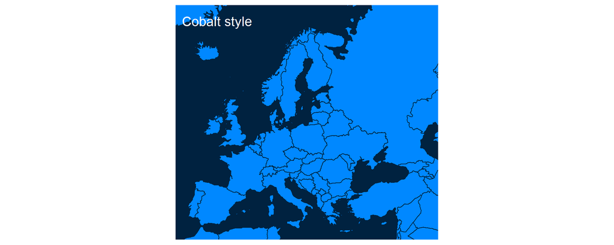

```r
qtm(Europe, style="cobalt", title="Cobalt style") # equivalent to: qtm(Europe) + tm_style_cobalt(title="Cobalt style")
```

Run `style_catalogue()` to create an extensive catalogue of the available styles. The default style is `tm_style_white`. This default can be changed with the global option called `tmap.style`, which can be get and set with `tmap_style`:

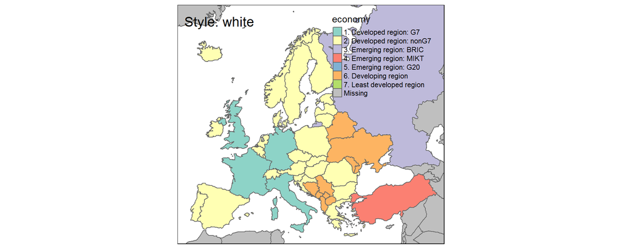

```r
# make a categorical map
qtm(Europe, fill="economy", title=paste("Style:", tmap_style()))
## current tmap style is "white"
```

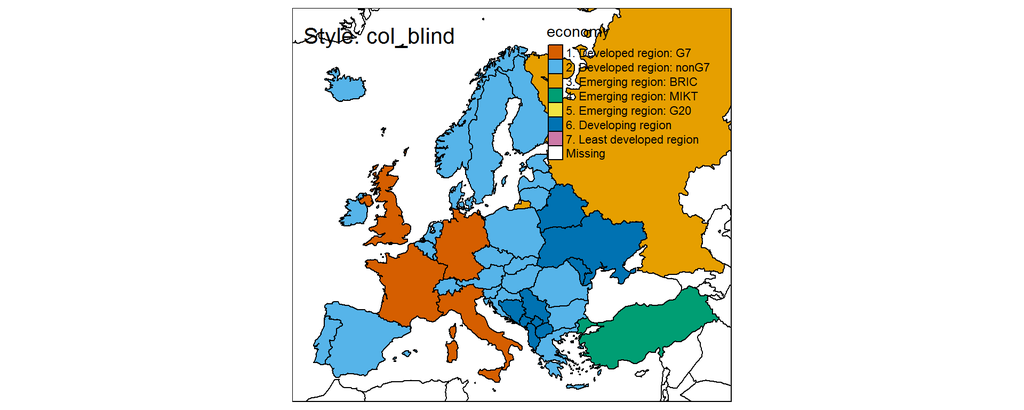

```r
# change to color-blind-friendly style
current_style <- tmap_style("col_blind")
## tmap style set to "col_blind"

# make a categorical map
qtm(Europe, fill="economy", title=paste("Style:", tmap_style()))
## current tmap style is "col_blind"
```

```r
# change back
tmap_style(current_style)
## tmap style set to "white"
```

Also, the outer and inner margins as well as the aspect ratio are determined with `tm_layout`:

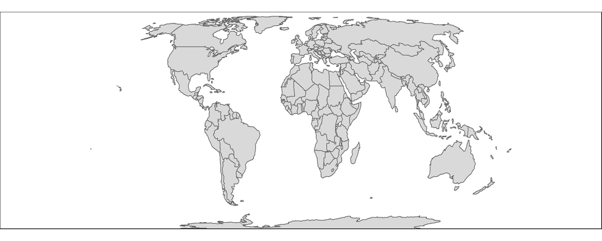

```r
(tm <- qtm(World) +
tm_layout(outer.margins=c(.05,0,.05,0),
    inner.margins=c(0,0,.02,0), asp=0))
```

The behaviour of `outer.margins`, `inner.margins`, and `asp` are correlated. To see the rectangles that these arguments determine, the design mode can be enabled:

```r
tm + tm_layout(design.mode=TRUE)
```

```
## ----------------aspect ratios-----------------------
## | specified (asp argument of tm_layout)   0.000000 |
## | device (yellow)                         2.500000 |
## | frame (blue)                            2.777778 |
## | master shape, World, (red)              1.979637 |
## ----------------------------------------------------
```

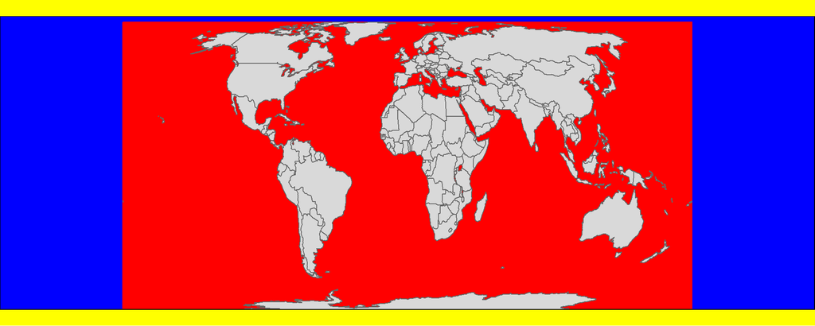

The red rectangle is the bounding box of the shape object. Both `inner.margins` and `asp` determine the measurements of the frame, indicated by the blue rectagle. Setting the left inner margin is useful to have extra space for the legend.

Setting the aspect ratio is handy when the plot is saved to an image with a specific resolution. For instance, to save a thematic World map as a png image of 1920 by 1080 pixels, the setting `outer.margins=0, asp=1920/1080` can be used. When `asp=0`, as in the example above, the aspect ratio of the device (given the outer margins) is taken. See `save_tmap`, which uses these tricks under the hood.

### Map attributes

The following demo shows how a world map can be enhanced with map attributes such as grid lines and a map compass.

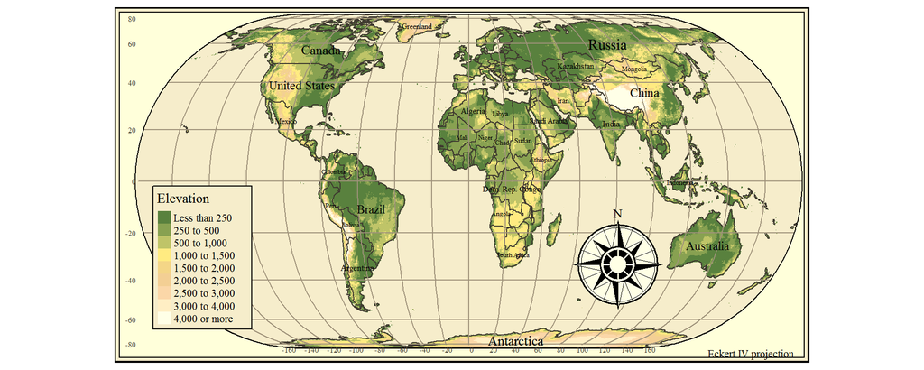

```r
tm_shape(land, projection="eck4") +
    tm_raster("elevation", breaks=c(-Inf, 250, 500, 1000, 1500, 2000, 2500, 3000, 4000, Inf),
        palette = terrain.colors(9), title="Elevation", auto.palette.mapping=FALSE) +
tm_shape(World) +
    tm_borders("grey20") +
    tm_grid(projection="longlat", labels.size = .5) +
    tm_text("name", size="AREA") +
tm_compass(position = c(.65, .15), color.light = "grey90") +
tm_credits("Eckert IV projection", position = c(.85, 0)) +
tm_style_classic(inner.margins=c(.04,.03, .02, .01), legend.position = c("left", "bottom"),
    legend.frame = TRUE, bg.color="lightblue", legend.bg.color="lightblue",
    earth.boundary = TRUE, space.color="grey90")
```

### Saving maps

A handy function for saving maps is `save_tmap`:

```r
tm <- tm_shape(World) +
    tm_fill("well_being", id="name", title="Well-being") +
    tm_format_World()
```

```r
save_tmap(tm, "World_map.png", width=1920, height=1080)
## Map saved to D:\tijn\rdevel\tmap\pkg\vignettes\World_map.png
## Resolution: 1920 by 1080 pixels
## Size: 6.4 by 3.6 inches (300 dpi)
```

This function can also save interactive maps to stand-alone HTML files:

```r
save_tmap(tm, "World_map.html")
## Interactive map saved to D:\tijn\rdevel\tmap\pkg\vignettes\World_map.html
```

See `vignette("tmap-modes")` for more on interactive maps.

### Complete work flow for creating thematic maps

Besides the `ggplot2`-style plotting functions, the package also offers functions to set up a work flow that is sufficient for most statistical applications.

- Input:
  - read ESRI shape files and write them with respectively `read_shape` and `write_shape`;
  - read GPX files with `read_GPX`
  - read Open Street Map data with `read_osm`
- Generate new spatial objects:
  - create a smooth map (raster, contour lines and dasymetric polygons) with `smooth_map`
  - create a smooth cover of a raster object with `smooth_raster_cover`
  - sample dots from polygons with `sample_dots`
  - bin spatial points to a raster with `points_to_raster`
  - convert polygons to a raster with `poly_to_raster`
- Handy tool functions:
  - create, extract or modify a bounding box with `bb`
  - get geocode based on location `geocode_OSM`
  - get the aspect ratio of a shape object with `get_asp_ratio`
  - get ID values of a shape object with `get_IDs`
  - append a data frame to a shape object with `append_data`
  - approximate area sizes of polygons with `approx_areas`
  - calculate density values with `calc_densities`
  - get the map projection with `get_projection`
  - set the map projection with `set_projection`
  - split a shape object with `split`
  - bind shape objects with `sbind`
  - color polygons with different colors for adjacent polygons with `map_coloring`
- Plotting shape objects:
  - with the quick plotting function `qtm`,
  - or with the main plotting method.
- Output:
  - plot in graphics device or view interactively in web browser or RStudio’s viewer pane `print`
  - create an animation (gif or mpeg) from a series of tmap plots with `animation_tmap`
  - save thematic maps with `save_tmap`
  - obtain leaflet widget with `tmap_leaflet`
  - write shape file with `write_shape`

### Tips n’ tricks

1. Selections can be made by treating the data.frame of the shape object:

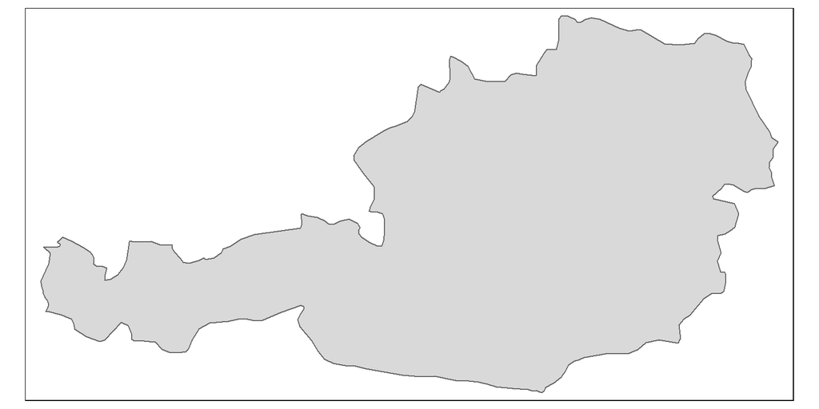

```r
tm_shape(Europe[Europe$name=="Austria", ]) +
    tm_polygons()
```

2. A one-item legend can be generated by using a categorical data variable with a one category, and assigning a single color value to palette:

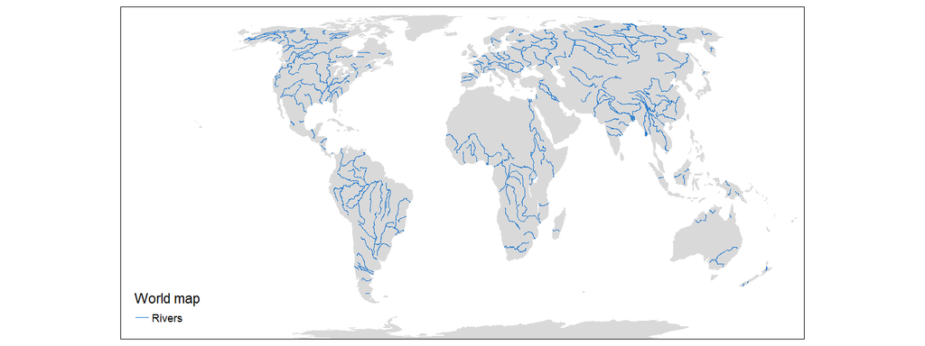

```r
data(World)

rivers$constant <- factor("Rivers")
tm_shape(World) +
    tm_fill() +
tm_shape(rivers) +
    tm_lines(col="constant", palette="dodgerblue3", title.col="World map") +
tm_format_World()
```

3. Each drawing element has a scalar argument called `scale`. The overall scaling and font sizes can be set by the `scale` argument in `tm_layout`.
4. Arugments of the bounding box function `bb` can be passed directly to `tm_shape`:

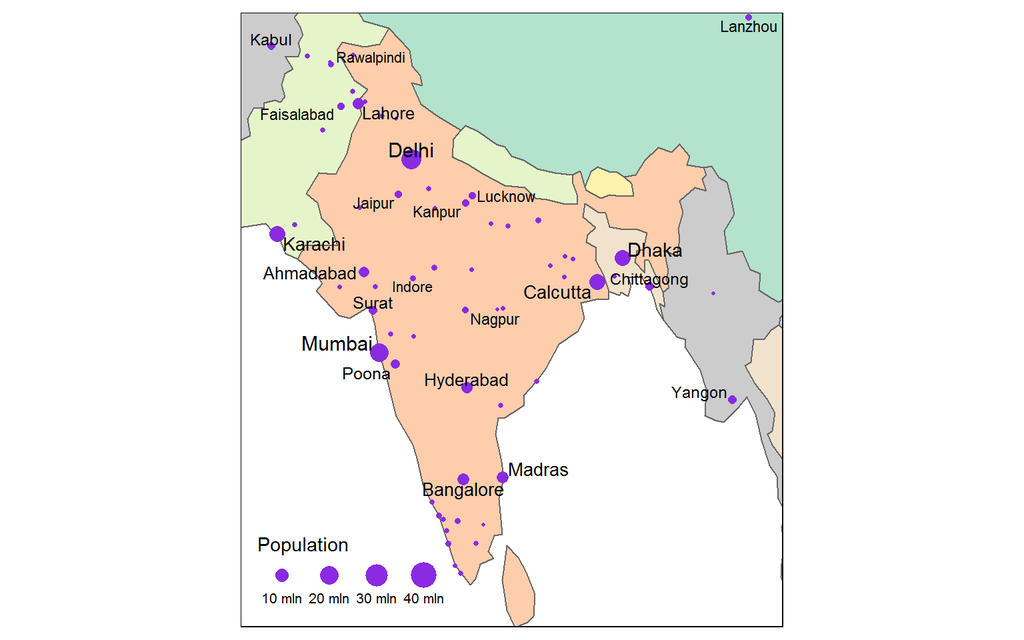

```r
tm_shape(World, bbox = "India") +
    tm_polygons("MAP_COLORS", palette="Pastel2") +
tm_shape(metro) +
    tm_bubbles("pop2010", title.size = "Population") +
    tm_text("name", size = "pop2010", legend.size.show = FALSE, root=8, size.lowerbound = .7, auto.placement = TRUE)
```